# Ps6

Weijia Li

# Part 1: Modelling Voter Turnout

## Describe the Data

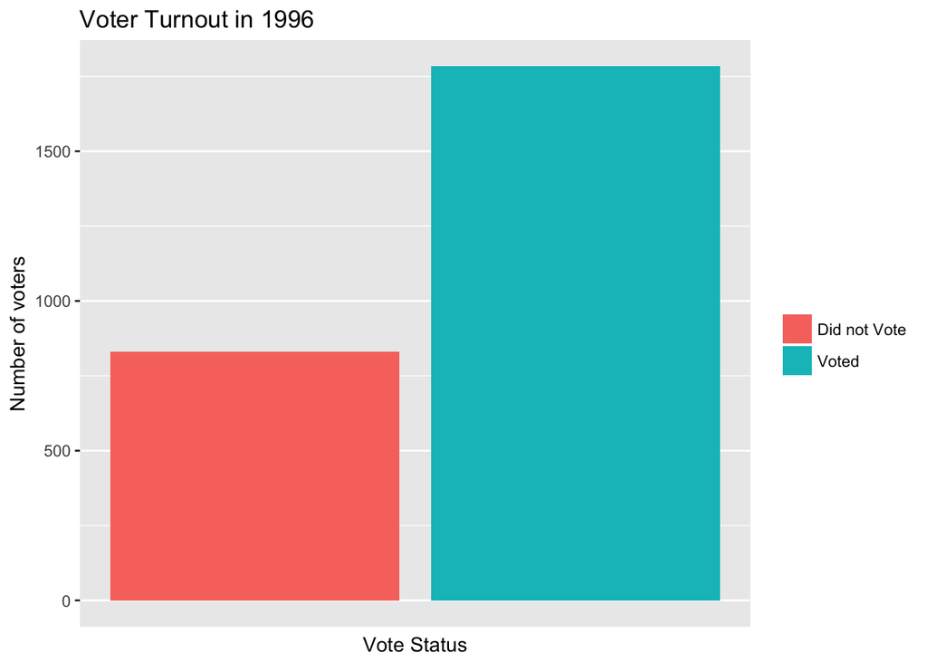

```r
ggplot(data.mhealth, aes(vote96, fill = ifelse(vote96 == 1, 'Voted', 'Did not Vote'))) +
  geom_bar() +
  labs(title = 'Voter Turnout in 1996', x = 'Vote Status', y = 'Number of voters') +
  scale_x_continuous(breaks = NULL) +
  guides(fill = guide_legend(title = ''))
```

```r
unconditional_probability = round(sum(data.mhealth$vote96, na.rm = TRUE) / length(data.mhealth$vote96), 2)
unconditional_probability
```

```
## [1] 0.63
```

The unconditional probability is 63%.

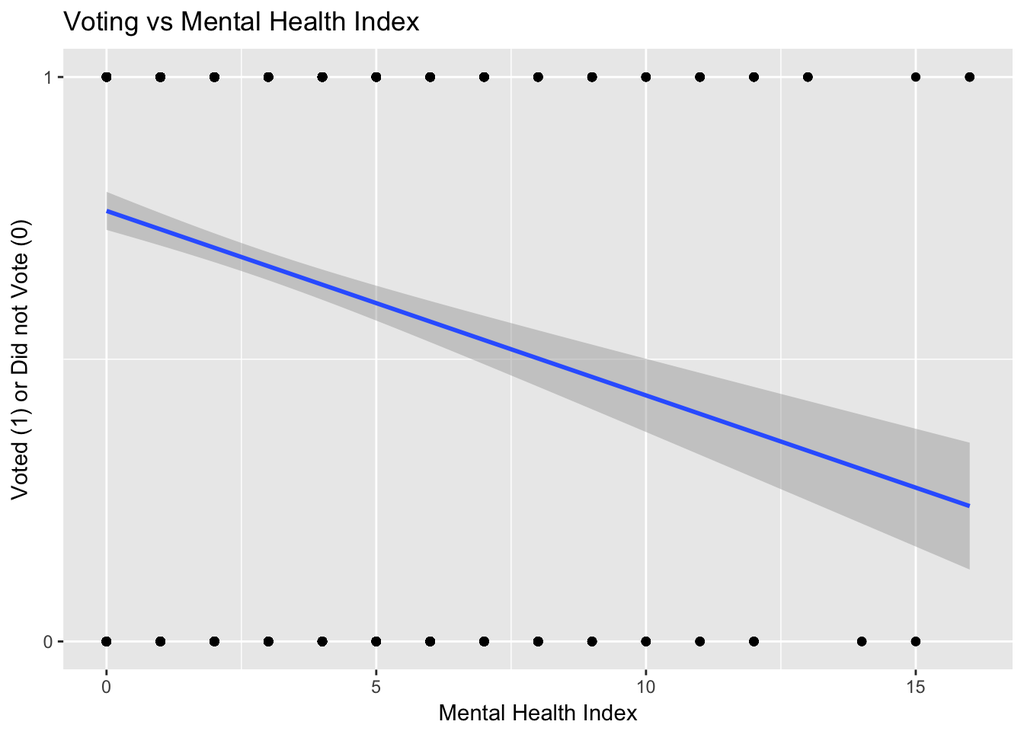

```r
ggplot(data.mhealth, aes(mhealth_sum, vote96)) +
  geom_point() +
  geom_smooth(method = lm) +
  scale_y_continuous(breaks = c(0, 1)) +
  labs(title = "Voting vs Mental Health Index",
       y = "Voted (1) or Did not Vote (0)",
       x = "Mental Health Index")
```

The plot shows that the worse the mental health(higher index), the less likely the person will vote.

The plot is problematic in the sense that, the vertical coverage of the linear line is a range in between 0 and 1 while the actual response variables are 0 or 1. By only looking at the line plot, the y value at each end does not explain the voting pattern.

## Basic Model

```r
logit.mh_mol <- glm(vote96 ~ mhealth_sum, data = data.mhealth, family = binomial)

logit2prob <- function(x){
  exp(x) / (1 + exp(x))
}

prob2odds <- function(x){
  x / (1 - x)
}

prob2logodds <- function(x){
  log(prob2odds(x))
}

data.mhealth %>%
  dplyr::select(vote96, mhealth_sum) %>%
  add_predictions(logit.mh_mol, var = 'logit') %>%
  mutate(prob = logit2prob(logit)) %>%
  mutate(odds = prob2odds(prob)) %>%
  na.omit() %>%
  {.} -> pred.mh_mol

coef(summary(logit.mh_mol))
```

```
##               Estimate Std. Error   z value     Pr(>|z|)
## (Intercept)  1.1392097 0.08444019 13.491321 1.759191e-41
## mhealth_sum -0.1434752 0.01968511 -7.288516 3.133883e-13
```

### 1.

The relationship between mental health and voter turnout is stastistically significant since p-value is about 3.133883e-13, which is very small.

### 2.

```r
coef <- logit.mh_mol$coefficients[2]
coef
```

```
## mhealth_sum
##  -0.1434752
```

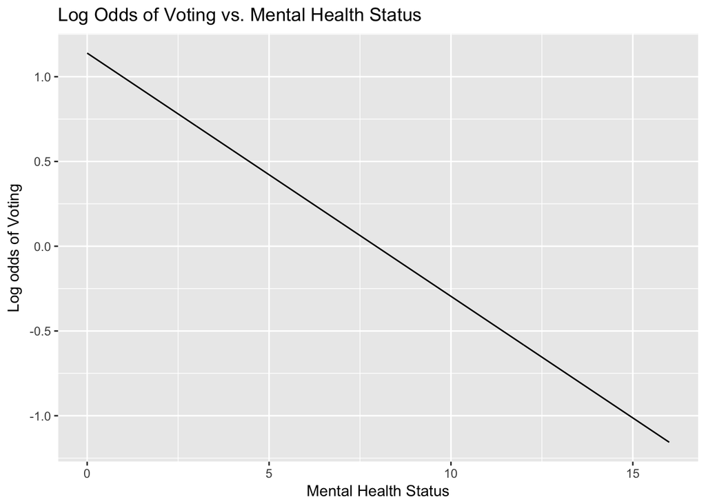

```r
ggplot(aes(mhealth_sum), data = pred.mh_mol) +
  geom_line(aes(y = logit)) +
  labs(title = "Log Odds of Voting vs. Mental Health Status",
       x = "Mental Health Status",
       y = "Log odds of Voting")
```

The estimated parameter for mental health is -0.1434752, this means the change in the log-odds associated with a one unit increase in `mhealth_sum` is -0.1434752.

### 3.

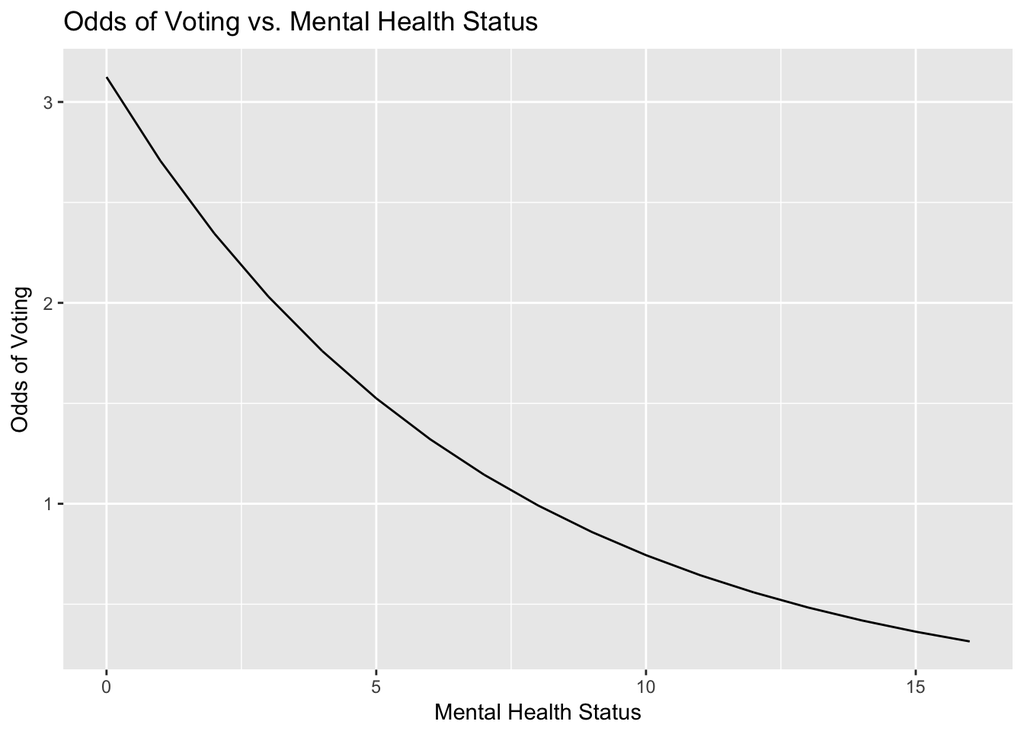

```r
ggplot(aes(mhealth_sum), data = pred.mh_mol) +
  geom_line(aes(y = odds)) +
  labs(title = "Odds of Voting vs. Mental Health Status",
       x = "Mental Health Status",
       y = "Odds of Voting")
```

### 4.

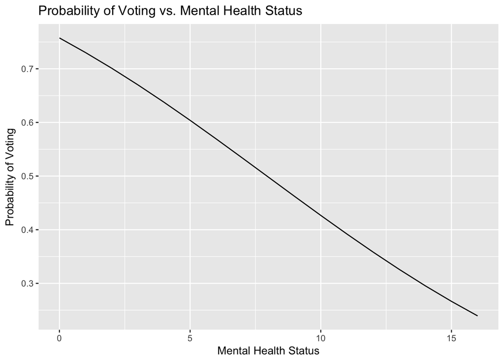

```r
ggplot(aes(mhealth_sum), data = pred.mh_mol) +
  geom_line(aes(y = prob)) +
  labs(title = "Probability of Voting vs. Mental Health Status",
       x = "Mental Health Status",
       y = "Probability of Voting")
```

```r
diff_grid <- tibble(mhealth_sum = 0:16) %>%
            add_predictions(logit.mh_mol, var = 'logit') %>%
            mutate(prob = logit2prob(logit))

dif1 = diff_grid[3,]$prob - diff_grid[2,]$prob
dif2 = diff_grid[7,]$prob - diff_grid[6,]$prob
dif1
```

```
## [1] -0.02917824
```

```r
dif2
```

```
## [1] -0.03477821
```

The first difference for an increase in the mental health index from 1 to 2 is: -0.02917824.  
The first difference for an increase in the mental health index from 5 to 6 is: -0.03477821.

```r
PRE <- function(model){
  y <- model$y

  y.hat <- round(model$fitted.values)

  E1 <- sum(y != median(y))
  E2 <- sum(y != y.hat)

  PRE <- (E1 - E2) / E1
  return(PRE)
}

pred.mh_mol <- pred.mh_mol %>%
  na.omit() %>%
  mutate(pred_vote = ifelse(prob > .5, 1, 0))

accuracy <- mean(pred.mh_mol$vote96 == pred.mh_mol$pred_vote)
round(accuracy, 2)
```

```
## [1] 0.68
```

```r
pre <- PRE(logit.mh_mol)
pre
```

```
## [1] 0.01616628
```

```r
auc_val = auc(pred.mh_mol$vote96, pred.mh_mol$pred_vote)
auc_val
```

```
## Area under the curve: 0.5401
```

Given a threshhold of .5, the accuracy rate is: 0.68 and the proportional reduction in error is: 0.0162; the AUC is 0.5401.

This is not very good model. The proportional reduction in error is `1.62%`, which is a tiny increase to the baseline rate. More than this, the AUC score only have increase 0.04 in AUC score than the baseline 0.5.

## Multiple Variable Model

### 1.

- The random component of the probability distribution: Bernoulli distribution

$$Pr(Y_i = y_i | \pi) = \pi_i^{y_i}(1 - \pi_i)^{1-y_i}$$
* The linear predictor:

$$\eta_i = \beta_0 + \beta_1 X_{mhealth_sum,i} + \beta_2 X_{age,i} + \beta_3 X_{educ,i} + \beta_4 X_{black,i} + \beta_5 X_{female,i} + \beta_6 X_{married,i} + \beta_7 X_{inc10,i}$$

- Link function is:

$$pi_i = \frac{e^{\eta_i}}{1 + e^{\eta_i}}$$

### 2. Estimate and report results

```r
logit_mul <- glm(vote96 ~ ., data=data.mhealth, family=binomial())
summary(logit_mul)
```

```
##
## Call:
## glm(formula = vote96 ~ ., family = binomial(), data = data.mhealth)
##
## Deviance Residuals:
##     Min       1Q   Median       3Q      Max
## -2.4843  -1.0258   0.5182   0.8428   2.0758
##
## Coefficients:
##              Estimate Std. Error z value Pr(>|z|)
## (Intercept) -4.304103   0.508103  -8.471  < 2e-16 ***
## mhealth_sum -0.089102   0.023642  -3.769 0.000164 ***
## age          0.042534   0.004814   8.835  < 2e-16 ***
## educ         0.228686   0.029532   7.744 9.65e-15 ***
## black        0.272984   0.202585   1.347 0.177820
## female      -0.016969   0.139972  -0.121 0.903507
## married      0.296915   0.153164   1.939 0.052557 .
## inc10        0.069614   0.026532   2.624 0.008697 **
## ---
## Signif. codes:  0 '***' 0.001 '**' 0.01 '*' 0.05 '.' 0.1 ' ' 1
##
## (Dispersion parameter for binomial family taken to be 1)
##
##     Null deviance: 1468.3  on 1164  degrees of freedom
## Residual deviance: 1241.8  on 1157  degrees of freedom
##   (1667 observations deleted due to missingness)
## AIC: 1257.8
##
## Number of Fisher Scoring iterations: 4
```

```r
logit.select <- stepAIC(logit_mul, trace = 0)
logit.select
```

```
##
## Call:  glm(formula = vote96 ~ mhealth_sum + age + educ + married + inc10,
##     family = binomial(), data = data.mhealth)
##
## Coefficients:
## (Intercept)  mhealth_sum          age         educ      married
##    -4.20013     -0.08833      0.04211      0.22527      0.29386
##       inc10
##     0.06624
##
## Degrees of Freedom: 1164 Total (i.e. Null);  1159 Residual
##   (1667 observations deleted due to missingness)
## Null Deviance:       1468
## Residual Deviance: 1244  AIC: 1256
```